# Results

## Training Dynamics

Training stability is assessed via rollout and evaluation reward curves. Curves are smoothed rolling means; higher values indicate better reward performance.

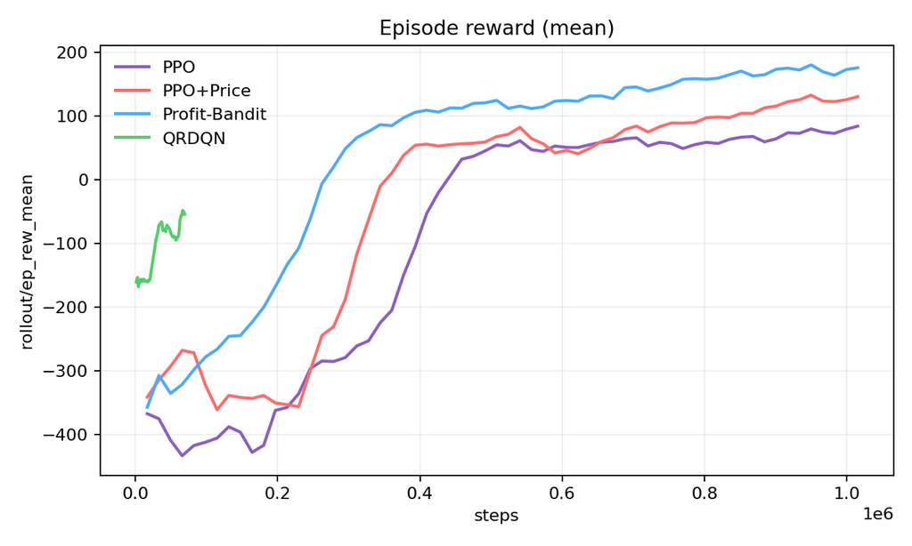

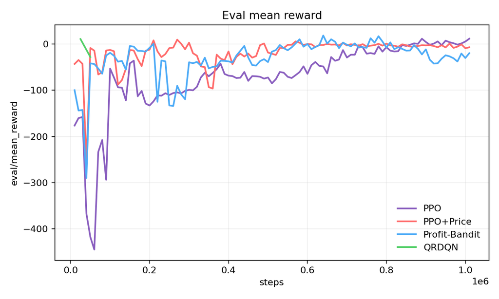

## Demonstrations of Trained Policies

### PPO Policy Demo

[video not shown]

### QRDQN Policy Demo

[video not shown]

## Findings

Taken together, these findings show that beating strong operational heuristics requires either a reward aligned with business KPIs, RL methods that encode queue and capacity structure explicitly, or hybrid approaches that integrate domain priors. Algorithmic sophistication alone cannot overcome a reward function that penalizes the very behaviors needed for profit.